# WGCNA Module Perturbation Test

F. V. Rodriguez

2026-04-10

# Overview

This notebook tests whether the intramodular connectivity loss observed in genotype-response modules (Inv4m DEGs) exceeds what random genotype label shuffling produces. The topology control uses leaf-gradient genes (photosynthesis + senescence hub genes from Ojeda 2026) that have real coexpression structure but are not differentially expressed between genotypes.

Both module sets come from separate consensus WGCNA pipeline runs (1000 iterations each), with bootstrap-validated stability (LFP from step 05).

**Gene set terminology:**

- **Genotype-response genes** – differentially expressed between CTRL and Inv4m plants; coexpression driven by the Inv4m introgression.
- **Leaf-gradient genes** – photosynthesis and senescence hub genes (Ojeda 2026); coexpression driven by the leaf developmental gradient, independent of Inv4m genotype.

**Prediction:** Genotype-response modules show significant kWithin loss; leaf-gradient modules do not.

# Setup

```r
library(here)
library(tidyverse)
library(WGCNA)
library(ggridges)
library(patchwork)

allowWGCNAThreads()
```

```
## Allowing multi-threading with up to 10 threads.
```

```r
set.seed(42)
```

```r
N_PERM <- 10000

# Genotype-response run
GR_RUN <- here("results/inversion_paper/field_perturbation/run_20251231_201332")
# Leaf-gradient run
LG_RUN <- here("results/inversion_paper/field_perturbation/run_leaf_gradient")

source(here("scripts/utils/setup_paths.R"))
paths <- setup_project_paths("inversion_paper")
```

# Load Pre-computed Data

```r
# Genotype-response consensus modules (from CTRL reference network)
gr_modules <- read_csv(
  file.path(GR_RUN, "04_consensus_networks", "ctrl", "consensus_modules.csv"),
  show_col_types = FALSE
)
gr_lfp <- read_csv(
  file.path(GR_RUN, "05_bootstrap_support", "ctrl", "module_support.csv"),
  show_col_types = FALSE
)
gr_preservation <- read_csv(
  file.path(GR_RUN, "06_preservation", "zsummary_table.csv"),
  show_col_types = FALSE
)

# Expression and metadata (shared across runs)
expr_gr <- readRDS(file.path(GR_RUN, "02_gene_filter", "filtered_expression.rds"))
sample_meta <- read_csv(
  file.path(GR_RUN, "01_data_prep", "sample_metadata.csv"),
  show_col_types = FALSE
)
SOFT_POWER <- readRDS(
  file.path(GR_RUN, "03_reference_network", "ctrl", "selected_power.rds")
)

# GO annotations
go_bp_file <- file.path(GR_RUN, "07_module_annotation", "top_BP_per_module_rrvgo.csv")
gr_go_terms <- if (file.exists(go_bp_file)) {
  go_bp <- read_csv(go_bp_file, show_col_types = FALSE)
  setNames(str_trunc(go_bp$Description, 35), go_bp$module_color)
} else {
  NULL
}

cat("Genotype-response:", nrow(gr_modules), "genes,",
    n_distinct(gr_modules$color[gr_modules$color != "grey"]), "modules\n")
```

```
## Genotype-response: 465 genes, 13 modules
```

```r
cat("Soft power:", SOFT_POWER, "\n")
```

```
## Soft power: 18
```

```r
# Leaf-gradient consensus modules (from CTRL reference network)
lg_modules <- read_csv(
  file.path(LG_RUN, "04_consensus_networks", "ctrl", "consensus_modules.csv"),
  show_col_types = FALSE
)
lg_lfp <- read_csv(
  file.path(LG_RUN, "05_bootstrap_support", "ctrl", "module_support.csv"),
  show_col_types = FALSE
)
lg_preservation <- read_csv(
  file.path(LG_RUN, "06_preservation", "zsummary_table.csv"),
  show_col_types = FALSE
)

# Leaf-gradient expression matrix
expr_lg <- readRDS(file.path(LG_RUN, "02_gene_filter", "filtered_expression.rds"))

# Remap leaf-gradient colors to avoid collisions with genotype-response
lg_color_remap <- c(
  turquoise = "sky",
  blue      = "peach",
  brown     = "jade",
  yellow    = "coral",
  green     = "lavender",
  grey      = "grey"
)
lg_color_hex <- c(
  sky      = "#5DA5DA",
  peach    = "#FAA43A",
  jade     = "#60BD68",
  coral    = "#F15854",
  lavender = "#B276B2",
  grey     = "grey"
)

cat("Leaf-gradient:", nrow(lg_modules), "genes,",
    n_distinct(lg_modules$color[lg_modules$color != "grey"]), "modules\n")
```

```
## Leaf-gradient: 218 genes, 5 modules
```

## GO Enrichment for Leaf-gradient Modules

Step 07 was skipped for the leaf-gradient run (DEG-specific inputs). Run GO BP enrichment here using clusterProfiler + rrvgo, matching the approach used for genotype-response modules.

```r
library(clusterProfiler)
library(rrvgo)
library(AnnotationHub)

TERM2GENE <- readRDS(here("data", "TERM2GENE.rds"))
TERM2NAME <- readRDS(here("data", "TERM2NAME.rds"))

# Universe = all genes in the full expression matrix
full_expr <- readRDS(file.path(GR_RUN, "01_data_prep", "combined_expression.rds"))
if (inherits(full_expr, "EList")) {
  go_universe <- rownames(full_expr$E)
} else {
  go_universe <- rownames(as.matrix(full_expr))
}
rm(full_expr)

# Gene lists per leaf-gradient module (use remapped colors, exclude grey)
lg_remapped <- lg_color_remap[lg_modules$color]
names(lg_remapped) <- lg_modules$gene
lg_gene_lists <- split(
  names(lg_remapped[lg_remapped != "grey"]),
  lg_remapped[lg_remapped != "grey"]
)

cat("Leaf-gradient modules for GO:", length(lg_gene_lists), "\n")
```

```
## Leaf-gradient modules for GO: 5
```

```r
cat("Module sizes:", paste(names(lg_gene_lists),
    sapply(lg_gene_lists, length), sep = "=", collapse = ", "), "\n")
```

```
## Module sizes: coral=26, jade=30, lavender=13, peach=64, sky=78
```

```r
lg_ego <- function(x) {
  enricher(
    gene = x,
    pvalueCutoff = 0.05,
    pAdjustMethod = "none",
    universe = go_universe,
    minGSSize = 10,
    maxGSSize = 500,
    qvalueCutoff = 0.2,
    TERM2GENE = TERM2GENE[TERM2GENE$GO %in% TERM2NAME[["BP"]]$go_id, ],
    TERM2NAME = TERM2NAME[["BP"]]
  )
}

lg_compGO <- compareCluster(
  geneCluster = lg_gene_lists,
  fun = lg_ego
)

lg_go_results <- as.data.frame(lg_compGO@compareClusterResult) |>
  dplyr::rename(module_color = Cluster) |>
  arrange(module_color, pvalue)

cat("Total enriched BP terms:", nrow(lg_go_results), "\n")
```

```
## Total enriched BP terms: 365
```

```r
cat("Terms per module:\n")
```

```
## Terms per module:
```

```r
print(table(lg_go_results$module_color))
```

```
##
##    coral     jade lavender    peach      sky
##       48       55       78      122       62
```

```r
# rrvgo semantic reduction
ah <- AnnotationHub()
org.Zm.eg.db <- ah[["AH119718"]]

lg_go_filtered <- lg_go_results |>
  filter(Count > 1) |>
  group_by(module_color) |>
  arrange(pvalue, .by_group = TRUE) |>
  ungroup()

lg_go_ids <- unique(lg_go_results$ID)
if (length(lg_go_ids) > 1) {
  simMatrix <- calculateSimMatrix(
    lg_go_ids,
    orgdb = org.Zm.eg.db,
    ont = "BP",
    method = "Rel"
  )
  scores <- setNames(-log10(lg_go_results$pvalue), lg_go_results$ID)
  reducedTerms <- reduceSimMatrix(
    simMatrix, scores, threshold = 0.7, orgdb = org.Zm.eg.db
  )
  lg_go_rrvgo <- lg_go_filtered |>
    filter(ID %in% reducedTerms$parent)
} else {
  lg_go_rrvgo <- lg_go_filtered
}

# Top 1 BP term per leaf-gradient module
lg_top_bp <- lg_go_rrvgo |>
  group_by(module_color) |>
  slice_min(pvalue, n = 1, with_ties = FALSE) |>
  ungroup() |>
  dplyr::select(module_color, ID, Description, pvalue, Count)

lg_go_terms <- setNames(
  str_trunc(lg_top_bp$Description, 35),
  lg_top_bp$module_color
)

cat("\nTop BP term per leaf-gradient module:\n")
```

```
##
## Top BP term per leaf-gradient module:
```

```r
print(lg_top_bp)
```

```
## # A tibble: 5 × 5
##   module_color ID         Description                         pvalue Count
##   <fct>        <chr>      <chr>                                <dbl> <int>
## 1 coral        GO:0016042 lipid catabolic process           8.63e- 4     3
## 2 jade         GO:0046395 carboxylic acid catabolic process 7.17e- 5     4
## 3 lavender     GO:0015979 photosynthesis                    2.77e-20    12
## 4 peach        GO:0015979 photosynthesis                    5.06e-40    31
## 5 sky          GO:0015979 photosynthesis                    6.09e-60    44
```

# Prepare Expression Matrices

```r
# Module color vectors
gr_colors <- setNames(gr_modules$color, gr_modules$gene)
gr_colors <- gr_colors[rownames(expr_gr)]

lg_colors <- lg_color_remap[lg_modules$color]
names(lg_colors) <- lg_modules$gene
lg_colors <- lg_colors[rownames(expr_lg)]

# Genotype labels
true_labels <- setNames(sample_meta$Genotype, sample_meta$sample_id)
all_samples <- sample_meta$sample_id
n_ctrl  <- sum(true_labels == "CTRL")
n_inv4m <- sum(true_labels == "Inv4m")
n_total <- length(true_labels)

# WGCNA format: samples x genes
datExpr_gr <- t(expr_gr[, all_samples])
datExpr_lg <- t(expr_lg[, all_samples])

cat("Genotype-response matrix:", nrow(datExpr_gr), "samples x",
    ncol(datExpr_gr), "genes\n")
```

```
## Genotype-response matrix: 43 samples x 465 genes
```

```r
cat("Leaf-gradient matrix:", nrow(datExpr_lg), "samples x",
    ncol(datExpr_lg), "genes\n")
```

```
## Leaf-gradient matrix: 43 samples x 218 genes
```

```r
cat("CTRL:", n_ctrl, "| Inv4m:", n_inv4m, "\n")
```

```
## CTRL: 20 | Inv4m: 23
```

# Supplementary Figure S5: Bootstrap Support

Two-panel figure showing CTRL consensus module bootstrap support (LFP) for both gene sets.

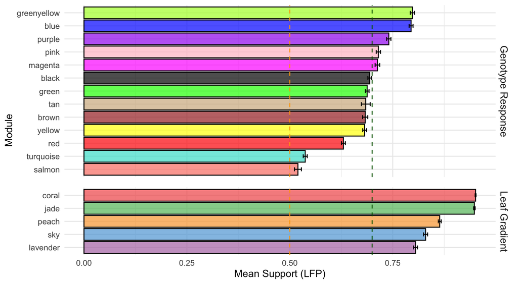

```r
STABILITY_STABLE   <- 0.70
STABILITY_MODERATE <- 0.50

# Combine both gene sets into one data frame
gr_support_df <- gr_lfp |>
  filter(color != "grey") |>
  mutate(
    display_color = color,
    fill_hex = color,
    gene_set = "Genotype Response DEGs"
  )

lg_support_df <- lg_lfp |>
  filter(color != "grey") |>
  mutate(
    display_color = lg_color_remap[color],
    fill_hex = lg_color_hex[lg_color_remap[color]],
    gene_set = "Leaf Gradient Hubs"
  )

support_df <- bind_rows(gr_support_df, lg_support_df) |>
  mutate(gene_set = recode(gene_set,
    "Genotype Response DEGs" = "Genotype Response",
    "Leaf Gradient Hubs" = "Leaf Gradient"))

p_support <- ggplot(
  support_df,
  aes(x = reorder(display_color, mean_lfp), y = mean_lfp, fill = fill_hex)
) +
  geom_col(color = "black", alpha = 0.7) +
  geom_errorbar(
    aes(ymin = pmax(0, mean_lfp - se_lfp),
        ymax = pmin(1, mean_lfp + se_lfp)),
    width = 0.3
  ) +
  geom_hline(yintercept = STABILITY_STABLE, linetype = "dashed",
             color = "darkgreen") +
  geom_hline(yintercept = STABILITY_MODERATE, linetype = "dashed",
             color = "orange") +
  scale_fill_identity() +
  coord_flip() +
  facet_grid(gene_set ~ ., scales = "free_y", space = "free_y") +
  theme_minimal(base_size = 14) +
  theme(panel.spacing.y = unit(1, "lines"),
        strip.text.y = element_text(size = 14)) +
  labs(x = "Module", y = "Mean Support (LFP)")

print(p_support)
```

```r
ggsave(file.path(paths$figures, "module_support.pdf"),
       p_support, width = 10, height = 5.5)
ggsave(file.path(paths$figures, "module_support.png"),
       p_support, width = 10, height = 8, dpi = 300)
```

# Helper Function

```r
compute_module_delta_k <- function(datExpr_a, datExpr_b, power, mod_colors) {
  adj_a <- adjacency(datExpr_a, power = power, type = "signed")
  adj_b <- adjacency(datExpr_b, power = power, type = "signed")

  k_a <- intramodularConnectivity(adj_a, mod_colors)
  k_b <- intramodularConnectivity(adj_b, mod_colors)

  delta_kWithin <- k_b$kWithin - k_a$kWithin
  delta_kOut    <- k_b$kOut - k_a$kOut

  module_ids <- unique(mod_colors[mod_colors != "grey" & !is.na(mod_colors)])
  list(
    kWithin = sapply(module_ids, function(m) {
      idx <- which(mod_colors == m)
      mean(delta_kWithin[idx], na.rm = TRUE)
    }),
    kOut = sapply(module_ids, function(m) {
      idx <- which(mod_colors == m)
      mean(delta_kOut[idx], na.rm = TRUE)
    })
  )
}
```

# Observed Delta kWithin

```r
ctrl_idx  <- which(true_labels == "CTRL")
inv4m_idx <- which(true_labels == "Inv4m")

obs_gr <- compute_module_delta_k(
  datExpr_gr[ctrl_idx, ], datExpr_gr[inv4m_idx, ],
  SOFT_POWER, gr_colors
)
observed_gr_kw  <- obs_gr$kWithin
observed_gr_out <- obs_gr$kOut

obs_lg <- compute_module_delta_k(
  datExpr_lg[ctrl_idx, ], datExpr_lg[inv4m_idx, ],
  SOFT_POWER, lg_colors
)
observed_lg_kw  <- obs_lg$kWithin
observed_lg_out <- obs_lg$kOut

cat("Observed mean delta kWithin per genotype-response module:\n")
```

```
## Observed mean delta kWithin per genotype-response module:
```

```r
print(round(sort(observed_gr_kw), 4))
```

```
##         tan       brown        blue      yellow        pink      purple
##     -3.0065     -2.3642     -1.6366     -1.4675     -1.3624     -1.1055
##       black greenyellow       green         red      salmon   turquoise
##     -0.8012     -0.6313     -0.6115     -0.5079     -0.3888     -0.2768
##     magenta
##     -0.1432
```

```r
cat("\nObserved mean delta kWithin per leaf-gradient module:\n")
```

```
##
## Observed mean delta kWithin per leaf-gradient module:
```

```r
print(round(sort(observed_lg_kw), 4))
```

```
##      sky     jade    coral    peach lavender
## -13.8198  -4.3914  -2.3498  -2.0876  -1.3633
```

```r
cat("\nObserved mean delta kOut per genotype-response module:\n")
```

```
##
## Observed mean delta kOut per genotype-response module:
```

```r
print(round(sort(observed_gr_out), 4))
```

```
##        pink      purple      yellow greenyellow       brown       black
##     -1.5068     -1.3451     -0.7252     -0.4355     -0.3494      0.2222
##        blue     magenta         red         tan   turquoise       green
##      0.2779      0.7208      0.8851      1.0936      1.1145      1.5777
##      salmon
##      1.6231
```

```r
cat("\nObserved mean delta kOut per leaf-gradient module:\n")
```

```
##
## Observed mean delta kOut per leaf-gradient module:
```

```r
print(round(sort(observed_lg_out), 4))
```

```
## lavender      sky    peach    coral     jade
##  -8.9763  -4.0923  -3.1630  -1.6293  -1.4351
```

# Genotype Label Permutation Test

Shuffle genotype labels 10,000 times, keeping group sizes fixed (20 CTRL, 23 Inv4m). For each permutation, recompute $\Delta k_{Within}$ and $\Delta k_{Out}$ for both gene sets. Module definitions remain fixed throughout.

```r
null_gr_kw  <- matrix(NA, nrow = N_PERM, ncol = length(observed_gr_kw))
null_gr_out <- matrix(NA, nrow = N_PERM, ncol = length(observed_gr_out))
colnames(null_gr_kw)  <- names(observed_gr_kw)
colnames(null_gr_out) <- names(observed_gr_out)

null_lg_kw  <- matrix(NA, nrow = N_PERM, ncol = length(observed_lg_kw))
null_lg_out <- matrix(NA, nrow = N_PERM, ncol = length(observed_lg_out))
colnames(null_lg_kw)  <- names(observed_lg_kw)
colnames(null_lg_out) <- names(observed_lg_out)

for (i in seq_len(N_PERM)) {
  perm_idx <- sample(n_total)
  pseudo_ctrl  <- perm_idx[1:n_ctrl]
  pseudo_inv4m <- perm_idx[(n_ctrl + 1):n_total]

  perm_gr <- compute_module_delta_k(
    datExpr_gr[pseudo_ctrl, ], datExpr_gr[pseudo_inv4m, ],
    SOFT_POWER, gr_colors
  )
  null_gr_kw[i, ]  <- perm_gr$kWithin
  null_gr_out[i, ] <- perm_gr$kOut

  perm_lg <- compute_module_delta_k(
    datExpr_lg[pseudo_ctrl, ], datExpr_lg[pseudo_inv4m, ],
    SOFT_POWER, lg_colors
  )
  null_lg_kw[i, ]  <- perm_lg$kWithin
  null_lg_out[i, ] <- perm_lg$kOut
}
```

# Results

## ECDF P-values

One-tailed test: fraction of permuted values $\leq$ observed (testing for connectivity loss more extreme than the null).

```r
# kWithin
pvals_gr_kw <- sapply(names(observed_gr_kw), function(m) {
  mean(null_gr_kw[, m] <= observed_gr_kw[m])
})
pvals_lg_kw <- sapply(names(observed_lg_kw), function(m) {
  mean(null_lg_kw[, m] <= observed_lg_kw[m])
})

# kOut (one-tailed: test for gain in inter-modular connectivity)
pvals_gr_out <- sapply(names(observed_gr_out), function(m) {
  mean(null_gr_out[, m] >= observed_gr_out[m])
})
pvals_lg_out <- sapply(names(observed_lg_out), function(m) {
  mean(null_lg_out[, m] >= observed_lg_out[m])
})
```

### Genotype-response Modules

```r
results_gr <- tibble(
  module = names(observed_gr_kw),
  gene_set = "Genotype Response DEGs",
  n_genes = sapply(names(observed_gr_kw), function(m)
    sum(gr_colors == m, na.rm = TRUE)),
  observed_mean_delta_k = round(observed_gr_kw, 4),
  null_mean = round(colMeans(null_gr_kw), 4),
  null_sd = round(apply(null_gr_kw, 2, sd), 4),
  ecdf_pvalue = round(pvals_gr_kw, 4)
) |>
  arrange(ecdf_pvalue)

results_gr
```

```
## # A tibble: 13 × 7
##    module   gene_set n_genes observed_mean_delta_k null_mean null_sd ecdf_pvalue
##    <chr>    <chr>      <int>                 <dbl>     <dbl>   <dbl>       <dbl>
##  1 brown    Genotyp…      46                -2.36    -0.0912   0.608      0
##  2 tan      Genotyp…      12                -3.01    -0.0518   0.974      0.0011
##  3 purple   Genotyp…      22                -1.11    -0.0426   0.433      0.0056
##  4 blue     Genotyp…      51                -1.64    -0.104    0.647      0.0078
##  5 pink     Genotyp…      30                -1.36    -0.0598   0.572      0.0094
##  6 yellow   Genotyp…      36                -1.47    -0.0782   0.737      0.0282
##  7 salmon   Genotyp…      11                -0.389   -0.0167   0.275      0.0936
##  8 greenye… Genotyp…      16                -0.631   -0.0394   0.469      0.106
##  9 red      Genotyp…      34                -0.508   -0.0643   0.391      0.128
## 10 black    Genotyp…      32                -0.801   -0.0751   0.648      0.134
## 11 green    Genotyp…      36                -0.612   -0.0741   0.652      0.205
## 12 magenta  Genotyp…      24                -0.143   -0.0466   0.269      0.361
## 13 turquoi… Genotyp…      55                -0.277   -0.135    1.04       0.441
```

### Leaf-gradient Modules

```r
results_lg <- tibble(
  module = names(observed_lg_kw),
  gene_set = "Leaf Gradient Hubs",
  n_genes = sapply(names(observed_lg_kw), function(m)
    sum(lg_colors == m)),
  observed_mean_delta_k = round(observed_lg_kw, 4),
  null_mean = round(colMeans(null_lg_kw), 4),
  null_sd = round(apply(null_lg_kw, 2, sd), 4),
  ecdf_pvalue = round(pvals_lg_kw, 4)
) |>
  arrange(ecdf_pvalue)

results_lg
```

```
## # A tibble: 5 × 7
##   module   gene_set  n_genes observed_mean_delta_k null_mean null_sd ecdf_pvalue
##   <chr>    <chr>       <int>                 <dbl>     <dbl>   <dbl>       <dbl>
## 1 coral    Leaf Gra…      26                 -2.35   -0.116     1.83       0.117
## 2 jade     Leaf Gra…      30                 -4.39   -0.129     3.73       0.164
## 3 sky      Leaf Gra…      78                -13.8    -0.299    12.4        0.190
## 4 lavender Leaf Gra…      13                 -1.36   -0.0403    1.83       0.283
## 5 peach    Leaf Gra…      64                 -2.09   -0.259     4.53       0.344
```

### BH FDR Correction Across All Tests

```r
all_results <- bind_rows(results_gr, results_lg)

# Joint FDR across both gene sets
n_gr <- length(pvals_gr_kw)
n_lg <- length(pvals_lg_kw)
all_kw_pvals <- c(pvals_gr_kw, pvals_lg_kw)
all_kw_fdr <- p.adjust(all_kw_pvals, method = "BH")
kw_fdr_gr <- setNames(all_kw_fdr[1:n_gr], names(pvals_gr_kw))
kw_fdr_lg <- setNames(all_kw_fdr[(n_gr + 1):(n_gr + n_lg)], names(pvals_lg_kw))

# kOut FDR
n_gr_out <- length(pvals_gr_out)
n_lg_out <- length(pvals_lg_out)
all_kout_pvals <- c(pvals_gr_out, pvals_lg_out)
all_kout_fdr <- p.adjust(all_kout_pvals, method = "BH")
kout_fdr_gr <- setNames(all_kout_fdr[1:n_gr_out], names(pvals_gr_out))
kout_fdr_lg <- setNames(all_kout_fdr[(n_gr_out + 1):(n_gr_out + n_lg_out)],
                         names(pvals_lg_out))

all_results <- all_results |>
  mutate(
    fdr = c(kw_fdr_gr[results_gr$module], kw_fdr_lg[results_lg$module]),
    sig = ifelse(fdr < 0.05, "*", "")
  ) |>
  arrange(ecdf_pvalue)

cat("Significant at FDR < 0.05:\n")
```

```
## Significant at FDR < 0.05:
```

```r
all_results |>
  filter(fdr < 0.05) |>
  dplyr::select(module, gene_set, n_genes, observed_mean_delta_k,
                ecdf_pvalue, fdr) |>
  print()
```

```
## # A tibble: 5 × 6
##   module gene_set               n_genes observed_mean_delta_k ecdf_pvalue    fdr
##   <chr>  <chr>                    <int>                 <dbl>       <dbl>  <dbl>
## 1 brown  Genotype Response DEGs      46                 -2.36      0      0
## 2 tan    Genotype Response DEGs      12                 -3.01      0.0011 0.0099
## 3 purple Genotype Response DEGs      22                 -1.11      0.0056 0.0336
## 4 blue   Genotype Response DEGs      51                 -1.64      0.0078 0.0338
## 5 pink   Genotype Response DEGs      30                 -1.36      0.0094 0.0338
```

```r
cat("\nAll leaf-gradient modules:\n")
```

```
##
## All leaf-gradient modules:
```

```r
all_results |>
  filter(gene_set == "Leaf Gradient Hubs") |>
  dplyr::select(module, n_genes, observed_mean_delta_k, ecdf_pvalue, fdr) |>
  print()
```

```
## # A tibble: 5 × 5
##   module   n_genes observed_mean_delta_k ecdf_pvalue   fdr
##   <chr>      <int>                 <dbl>       <dbl> <dbl>
## 1 coral         26                 -2.35       0.117 0.220
## 2 jade          30                 -4.39       0.164 0.246
## 3 sky           78                -13.8        0.190 0.262
## 4 lavender      13                 -1.36       0.283 0.340
## 5 peach         64                 -2.09       0.344 0.383
```

## Save Permutation Results

```r
OUTPUT_DIR <- file.path(GR_RUN, "06_preservation")

write_csv(all_results,
          file.path(OUTPUT_DIR,
                    "permutation_delta_kWithin_results.csv"))
saveRDS(
  list(
    observed_gr_kw = observed_gr_kw,
    observed_lg_kw = observed_lg_kw,
    observed_gr_out = observed_gr_out,
    observed_lg_out = observed_lg_out,
    null_gr_kw = null_gr_kw,
    null_lg_kw = null_lg_kw,
    null_gr_out = null_gr_out,
    null_lg_out = null_lg_out,
    pvals_gr_kw = pvals_gr_kw,
    pvals_lg_kw = pvals_lg_kw,
    pvals_gr_out = pvals_gr_out,
    pvals_lg_out = pvals_lg_out,
    gr_colors = gr_colors,
    lg_colors = lg_colors
  ),
  file.path(OUTPUT_DIR, "permutation_delta_kWithin.rds")
)
```

# Visualization

## Z-score Ridge Plots (kWithin)

Two-panel figure comparing connectivity disruption in genotype-response modules versus leaf-gradient modules. Z-scores are computed per module as $(observed - mean_{null}) / sd_{null}$. Red lines mark observed values.

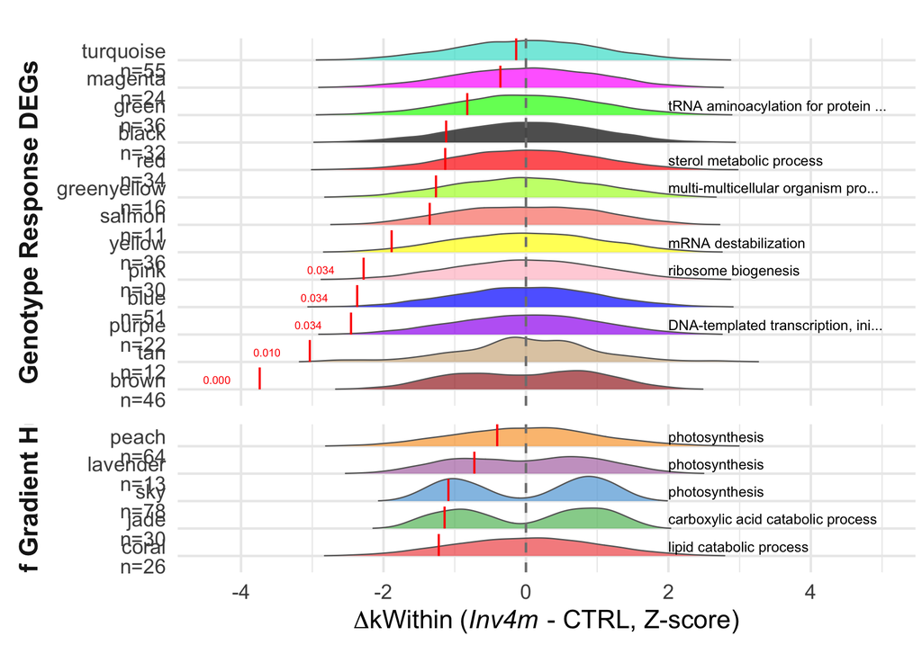

```r
# Z-score genotype-response null distributions
gr_null_mean <- colMeans(null_gr_kw)
gr_null_sd   <- apply(null_gr_kw, 2, sd)
gr_null_z    <- null_gr_kw
for (m in colnames(gr_null_z)) {
  gr_null_z[, m] <- (gr_null_z[, m] - gr_null_mean[m]) / gr_null_sd[m]
}
gr_obs_z <- (observed_gr_kw - gr_null_mean) / gr_null_sd

# Z-score leaf-gradient null distributions
lg_null_mean <- colMeans(null_lg_kw)
lg_null_sd   <- apply(null_lg_kw, 2, sd)
lg_null_z    <- null_lg_kw
for (m in colnames(lg_null_z)) {
  lg_null_z[, m] <- (lg_null_z[, m] - lg_null_mean[m]) / lg_null_sd[m]
}
lg_obs_z <- (observed_lg_kw - lg_null_mean) / lg_null_sd

# Module sizes for y-axis labels
gr_mod_sizes <- sapply(colnames(gr_null_z), function(m)
  sum(gr_colors == m, na.rm = TRUE))
lg_mod_sizes <- sapply(colnames(lg_null_z), function(m)
  sum(lg_colors == m))

# Build combined density data
gr_density <- map_dfr(colnames(gr_null_z), function(m) {
  tibble(module = sprintf("%s\nn=%d", m, gr_mod_sizes[m]),
         fill_hex = m, z_value = gr_null_z[, m],
         gene_set = "Genotype Response DEGs")
})
lg_density <- map_dfr(colnames(lg_null_z), function(m) {
  tibble(module = sprintf("%s\nn=%d", m, lg_mod_sizes[m]),
         fill_hex = lg_color_hex[m], z_value = lg_null_z[, m],
         gene_set = "Leaf Gradient Hubs")
})
density_kw <- bind_rows(gr_density, lg_density)

# Build combined points data
gr_points <- tibble(
  module = sprintf("%s\nn=%d", names(gr_obs_z), gr_mod_sizes[names(gr_obs_z)]),
  fill_hex = names(gr_obs_z),
  z_observed = gr_obs_z, fdr = kw_fdr_gr[names(gr_obs_z)],
  gene_set = "Genotype Response DEGs"
)
lg_points <- tibble(
  module = sprintf("%s\nn=%d", names(lg_obs_z), lg_mod_sizes[names(lg_obs_z)]),
  fill_hex = lg_color_hex[names(lg_obs_z)],
  z_observed = lg_obs_z, fdr = kw_fdr_lg[names(lg_obs_z)],
  gene_set = "Leaf Gradient Hubs"
)
points_kw <- bind_rows(gr_points, lg_points)

# Order modules by z_observed WITHIN each gene_set, compute per-facet rank
points_kw <- points_kw |>
  group_by(gene_set) |>
  arrange(z_observed, .by_group = TRUE) |>
  mutate(facet_rank = row_number()) |>
  ungroup()

# Set factor levels per facet ordering
mod_order <- points_kw |> arrange(gene_set, facet_rank) |> pull(module)
density_kw$module <- factor(density_kw$module, levels = mod_order)
points_kw$module  <- factor(points_kw$module, levels = mod_order)

# Propagate facet_rank to density data
density_kw <- density_kw |>
  left_join(points_kw |> dplyr::select(module, gene_set, facet_rank) |> distinct(),
            by = c("module", "gene_set"))

# Build fill color map (module label -> hex)
fill_map <- setNames(points_kw$fill_hex, as.character(points_kw$module))

# GO term annotations
gr_go_df <- if (!is.null(gr_go_terms)) {
  tibble(
    module = sprintf("%s\nn=%d", names(gr_go_terms),
                     gr_mod_sizes[names(gr_go_terms)]),
    go_desc = unname(gr_go_terms), gene_set = "Genotype Response DEGs"
  ) |> filter(module %in% levels(density_kw$module))
}
lg_go_df <- if (!is.null(lg_go_terms)) {
  tibble(
    module = sprintf("%s\nn=%d", names(lg_go_terms),
                     lg_mod_sizes[names(lg_go_terms)]),
    go_desc = unname(lg_go_terms), gene_set = "Leaf Gradient Hubs"
  ) |> filter(module %in% levels(density_kw$module))
}
go_df <- bind_rows(gr_go_df, lg_go_df) |>
  mutate(module = factor(module, levels = levels(density_kw$module))) |>
  left_join(points_kw |> dplyr::select(module, gene_set, facet_rank) |> distinct(),
            by = c("module", "gene_set")) |>
  mutate(y_pos = facet_rank + 0.35)

p_kw <- ggplot(density_kw, aes(x = z_value, y = module, fill = module)) +
  geom_density_ridges(color = "grey40", alpha = 0.7,
                      scale = 0.9, rel_min_height = 0.01) +
  scale_fill_manual(values = fill_map) +
  guides(fill = "none") +
  geom_vline(xintercept = 0, linetype = "dashed", color = "grey50") +
  geom_segment(
    data = points_kw,
    aes(x = z_observed, xend = z_observed,
        y = facet_rank, yend = facet_rank + 0.8),
    color = "red", linewidth = 0.8, inherit.aes = FALSE
  ) +
  geom_text(
    data = points_kw |> filter(fdr < 0.05),
    aes(x = z_observed - 0.6, y = facet_rank + 0.35,
        label = sprintf("%.3f", fdr)),
    color = "red", size = 3, hjust = 0.5, inherit.aes = FALSE
  ) +
  geom_text(
    data = go_df,
    aes(x = 2, y = y_pos, label = go_desc),
    hjust = 0, size = 14 * 0.8 / .pt,
    inherit.aes = FALSE
  ) +
  scale_x_continuous(limits = c(NA, 5), breaks = seq(-10, 10, 2)) +
  facet_grid(gene_set ~ ., scales = "free_y", space = "free_y",
             switch = "y") +
  theme_minimal(base_size = 20) +
  theme(panel.spacing.y = unit(1, "lines"),
        strip.placement = "outside",
        strip.background = element_blank(),
        strip.text.y.left = element_text(size = 20, face = "bold",
                                         angle = 90),
        axis.text.y = element_text(lineheight = 0.8, vjust = 0.5),
        plot.margin = margin(t = 30, r = 5, b = 5, l = 5)) +
  labs(y = NULL,
       x = expression(Delta * "kWithin" ~ "(" * italic("Inv4m") *
                      " - CTRL, Z-score)"))

print(p_kw)
```

```r
ggsave(file.path(OUTPUT_DIR, "zscore_density_kWithin.pdf"),
       p_kw, width = 10, height = 7)
ggsave(file.path(OUTPUT_DIR, "zscore_density_kWithin.png"),
       p_kw, width = 10, height = 7, dpi = 300)
saveRDS(p_kw, file.path(OUTPUT_DIR, "zscore_density_kWithin.rds"))
```

## Z-score Ridge Plots (kOut)

Same approach for inter-modular connectivity ($\Delta k_{Out}$).

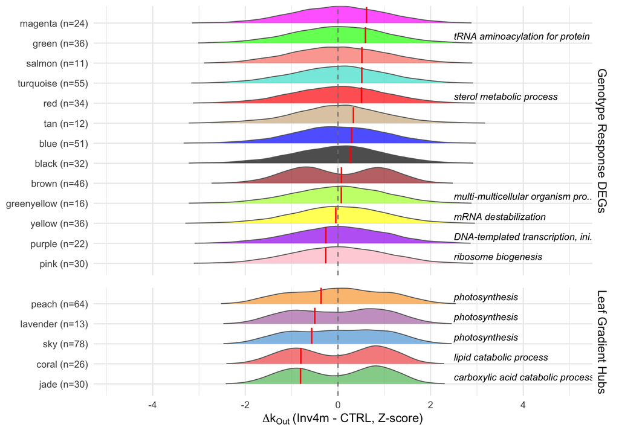

```r
# Z-score kOut
gr_null_mean_out <- colMeans(null_gr_out)
gr_null_sd_out   <- apply(null_gr_out, 2, sd)
gr_null_z_out    <- null_gr_out
for (m in colnames(gr_null_z_out)) {
  gr_null_z_out[, m] <- (gr_null_z_out[, m] - gr_null_mean_out[m]) / gr_null_sd_out[m]
}
gr_obs_z_out <- (observed_gr_out - gr_null_mean_out) / gr_null_sd_out

lg_null_mean_out <- colMeans(null_lg_out)
lg_null_sd_out   <- apply(null_lg_out, 2, sd)
lg_null_z_out    <- null_lg_out
for (m in colnames(lg_null_z_out)) {
  lg_null_z_out[, m] <- (lg_null_z_out[, m] - lg_null_mean_out[m]) / lg_null_sd_out[m]
}
lg_obs_z_out <- (observed_lg_out - lg_null_mean_out) / lg_null_sd_out

# Build combined density data
gr_density_out <- map_dfr(colnames(gr_null_z_out), function(m) {
  tibble(module = sprintf("%s (n=%d)", m, gr_mod_sizes[m]),
         fill_hex = m, z_value = gr_null_z_out[, m],
         gene_set = "Genotype Response DEGs")
})
lg_density_out <- map_dfr(colnames(lg_null_z_out), function(m) {
  tibble(module = sprintf("%s (n=%d)", m, lg_mod_sizes[m]),
         fill_hex = lg_color_hex[m], z_value = lg_null_z_out[, m],
         gene_set = "Leaf Gradient Hubs")
})
density_kout <- bind_rows(gr_density_out, lg_density_out)

# Build combined points data
gr_points_out <- tibble(
  module = sprintf("%s (n=%d)", names(gr_obs_z_out), gr_mod_sizes[names(gr_obs_z_out)]),
  fill_hex = names(gr_obs_z_out),
  z_observed = gr_obs_z_out, fdr = kout_fdr_gr[names(gr_obs_z_out)],
  gene_set = "Genotype Response DEGs"
)
lg_points_out <- tibble(
  module = sprintf("%s (n=%d)", names(lg_obs_z_out), lg_mod_sizes[names(lg_obs_z_out)]),
  fill_hex = lg_color_hex[names(lg_obs_z_out)],
  z_observed = lg_obs_z_out, fdr = kout_fdr_lg[names(lg_obs_z_out)],
  gene_set = "Leaf Gradient Hubs"
)
points_kout <- bind_rows(gr_points_out, lg_points_out)

# Order modules by z_observed WITHIN each gene_set, compute per-facet rank
points_kout <- points_kout |>
  group_by(gene_set) |>
  arrange(z_observed, .by_group = TRUE) |>
  mutate(facet_rank = row_number()) |>
  ungroup()

mod_order_out <- points_kout |> arrange(gene_set, facet_rank) |> pull(module)
density_kout$module <- factor(density_kout$module, levels = mod_order_out)
points_kout$module  <- factor(points_kout$module, levels = mod_order_out)

density_kout <- density_kout |>
  left_join(points_kout |> dplyr::select(module, gene_set, facet_rank) |> distinct(),
            by = c("module", "gene_set"))

fill_map_out <- setNames(points_kout$fill_hex, as.character(points_kout$module))

# GO annotations with per-facet rank
go_df_out <- bind_rows(gr_go_df, lg_go_df) |>
  mutate(module = factor(module, levels = levels(density_kout$module))) |>
  left_join(points_kout |> dplyr::select(module, gene_set, facet_rank) |> distinct(),
            by = c("module", "gene_set")) |>
  mutate(y_pos = facet_rank + 0.35)

p_kout <- ggplot(density_kout, aes(x = z_value, y = module, fill = module)) +
  geom_density_ridges(color = "grey40", alpha = 0.7,
                      scale = 0.9, rel_min_height = 0.01) +
  scale_fill_manual(values = fill_map_out) +
  guides(fill = "none") +
  geom_vline(xintercept = 0, linetype = "dashed", color = "grey50") +
  geom_segment(
    data = points_kout,
    aes(x = z_observed, xend = z_observed,
        y = facet_rank, yend = facet_rank + 0.8),
    color = "red", linewidth = 0.8, inherit.aes = FALSE
  ) +
  geom_text(
    data = points_kout |> filter(fdr < 0.05),
    aes(x = z_observed - 0.6, y = facet_rank + 0.35,
        label = sprintf("FDR=%.3f", fdr)),
    color = "red", size = 3, hjust = 0.5, inherit.aes = FALSE
  ) +
  geom_text(
    data = go_df_out,
    aes(x = 2.5, y = y_pos, label = go_desc),
    hjust = 0, size = 14 * 0.8 / .pt, fontface = "italic",
    inherit.aes = FALSE
  ) +
  scale_x_continuous(limits = c(NA, 5), breaks = seq(-10, 10, 2)) +
  facet_grid(gene_set ~ ., scales = "free_y", space = "free_y") +
  theme_minimal(base_size = 14) +
  theme(panel.spacing.y = unit(1, "lines"),
        strip.text.y = element_text(size = 14)) +
  labs(y = NULL, x = expression(Delta * k[Out] ~ "(Inv4m - CTRL, Z-score)"))

print(p_kout)
```

```r
ggsave(file.path(OUTPUT_DIR, "zscore_density_kOut.pdf"),
       p_kout, width = 10, height = 7)
ggsave(file.path(OUTPUT_DIR, "zscore_density_kOut.png"),
       p_kout, width = 10, height = 7, dpi = 300)
```

## kOut: CTRL vs Inv4m Gene-level Scatter

Each point is a gene; axes are kOut in CTRL vs kOut in Inv4m. Points above the diagonal gained inter-modular connectivity. Colored by module.

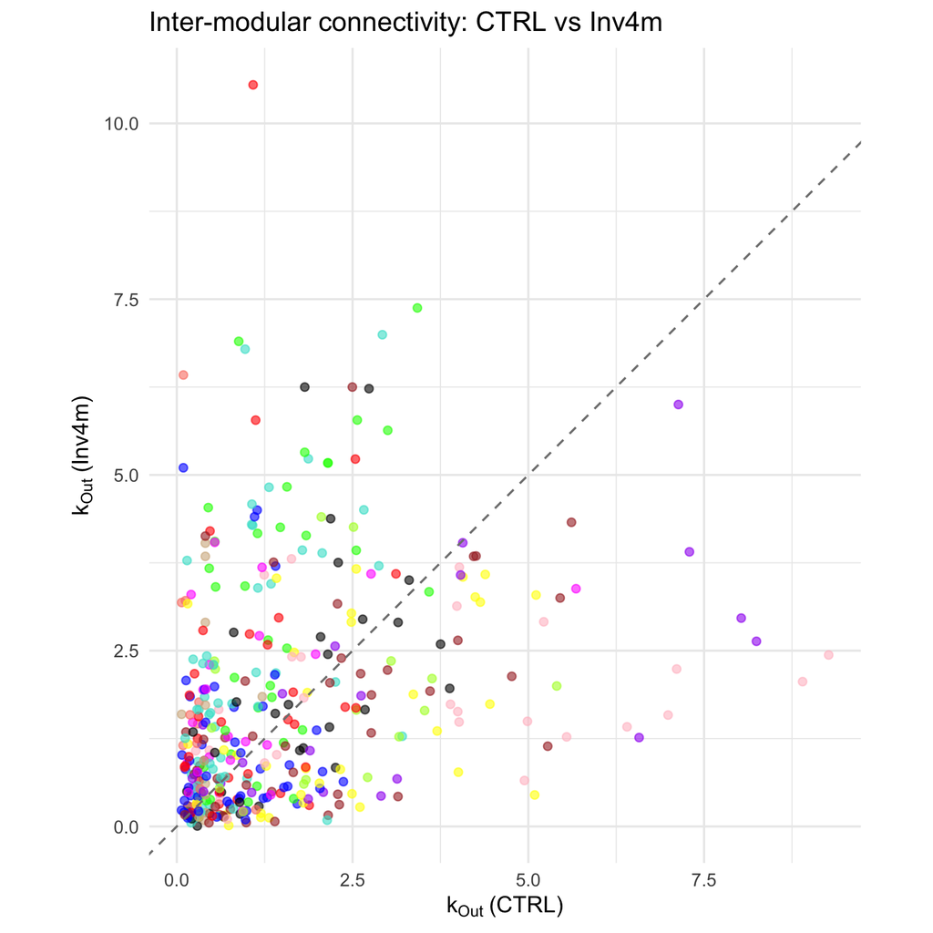

```r
# Gene-level kOut from genotype-response adjacencies
adj_ctrl_gr  <- adjacency(datExpr_gr[ctrl_idx, ], power = SOFT_POWER, type = "signed")
adj_inv4m_gr <- adjacency(datExpr_gr[inv4m_idx, ], power = SOFT_POWER, type = "signed")
k_ctrl_gr  <- intramodularConnectivity(adj_ctrl_gr, gr_colors)
k_inv4m_gr <- intramodularConnectivity(adj_inv4m_gr, gr_colors)

kout_scatter <- tibble(
  gene = rownames(k_ctrl_gr),
  module = gr_colors[rownames(k_ctrl_gr)],
  kOut_CTRL = k_ctrl_gr$kOut,
  kOut_Inv4m = k_inv4m_gr$kOut
) |>
  filter(module != "grey", !is.na(module))

p_kout_scatter <- ggplot(
  kout_scatter,
  aes(x = kOut_CTRL, y = kOut_Inv4m, color = module)
) +
  geom_point(alpha = 0.6, size = 2) +
  geom_abline(slope = 1, intercept = 0,
              linetype = "dashed", color = "grey50") +
  scale_color_identity() +
  theme_minimal(base_size = 14) +
  labs(
    x = expression(k[Out] ~ "(CTRL)"),
    y = expression(k[Out] ~ "(Inv4m)"),
    title = "Inter-modular connectivity: CTRL vs Inv4m"
  ) +
  coord_equal()

print(p_kout_scatter)
```

```r
cat("Genes above diagonal (kOut gain):",
    sum(kout_scatter$kOut_Inv4m > kout_scatter$kOut_CTRL),
    "of", nrow(kout_scatter), "\n")
```

```
## Genes above diagonal (kOut gain): 218 of 405
```

```r
wt_kout <- wilcox.test(kout_scatter$kOut_Inv4m,
                        kout_scatter$kOut_CTRL,
                        paired = TRUE)
cat("Paired Wilcoxon p:", format.pval(wt_kout$p.value), "\n")
```

```
## Paired Wilcoxon p: 0.012449
```

```r
ggsave(file.path(OUTPUT_DIR, "kOut_CTRL_vs_Inv4m_scatter.pdf"),
       p_kout_scatter, width = 8, height = 8)
ggsave(file.path(OUTPUT_DIR, "kOut_CTRL_vs_Inv4m_scatter.png"),
       p_kout_scatter, width = 8, height = 8, dpi = 300)
```

## |logFC| vs Delta kWithin

Scatterplot of Inv4m expression effect size against connectivity change, for genotype-response and leaf-gradient genes separately.

```r
# Load DEG effects
effects <- read_csv(
  file.path(paths$intermediate, "predictor_effects_leaf_interaction_model.csv"),
  show_col_types = FALSE
)
inv4m_effects <- effects |>
  filter(grepl("Inv4m", predictor), !grepl(":", predictor)) |>
  dplyr::select(gene, logFC, adj.P.Val)

# Gene-level delta kWithin for genotype-response genes
adj_ctrl_gr  <- adjacency(datExpr_gr[ctrl_idx, ], power = SOFT_POWER, type = "signed")
adj_inv4m_gr <- adjacency(datExpr_gr[inv4m_idx, ], power = SOFT_POWER, type = "signed")
k_ctrl_gr  <- intramodularConnectivity(adj_ctrl_gr, gr_colors)
k_inv4m_gr <- intramodularConnectivity(adj_inv4m_gr, gr_colors)

gr_dk <- tibble(
  gene = rownames(k_ctrl_gr),
  delta_kWithin = k_inv4m_gr$kWithin - k_ctrl_gr$kWithin,
  group = "Genotype Response DEGs"
)

# Gene-level delta kWithin for leaf-gradient genes
adj_ctrl_lg  <- adjacency(datExpr_lg[ctrl_idx, ], power = SOFT_POWER, type = "signed")
adj_inv4m_lg <- adjacency(datExpr_lg[inv4m_idx, ], power = SOFT_POWER, type = "signed")
k_ctrl_lg  <- intramodularConnectivity(adj_ctrl_lg, lg_colors)
k_inv4m_lg <- intramodularConnectivity(adj_inv4m_lg, lg_colors)

lg_dk <- tibble(
  gene = names(lg_colors),
  delta_kWithin = k_inv4m_lg$kWithin - k_ctrl_lg$kWithin,
  group = "Leaf Gradient Hubs"
)

# Merge with logFC
scatter_df <- bind_rows(gr_dk, lg_dk) |>
  left_join(inv4m_effects |> dplyr::select(gene, logFC, adj.P.Val), by = "gene") |>
  mutate(
    abs_logFC = abs(logFC),
    neg_log10p = -log10(adj.P.Val)
  ) |>
  filter(!is.na(logFC))

# Correlations per group
cor_logfc <- scatter_df |>
  group_by(group) |>
  summarise(rho = cor(abs_logFC, delta_kWithin, method = "spearman"),
            .groups = "drop")
cat("Spearman correlations (|logFC| vs delta_k):\n")
```

```
## Spearman correlations (|logFC| vs delta_k):
```

```r
print(cor_logfc)
```

```
## # A tibble: 2 × 2
##   group                      rho
##   <chr>                    <dbl>
## 1 Genotype Response DEGs  0.162
## 2 Leaf Gradient Hubs     -0.0241
```

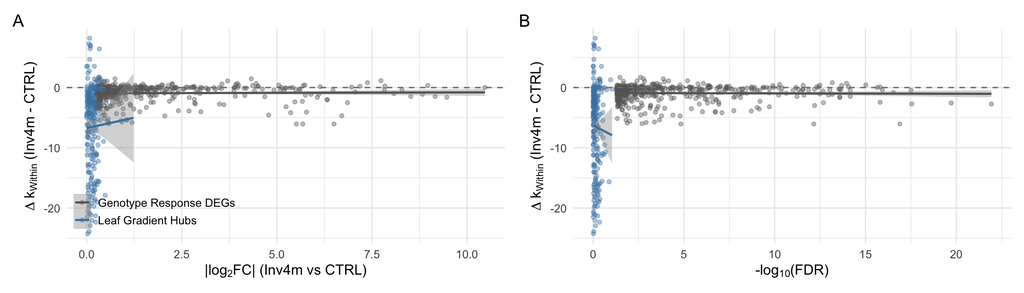

```r
# Panel A: |logFC| vs delta kWithin
p_logfc <- ggplot(scatter_df, aes(x = abs_logFC, y = delta_kWithin, color = group)) +
  geom_point(alpha = 0.4, size = 1.5) +
  geom_smooth(method = "lm", se = TRUE, linewidth = 1) +
  geom_hline(yintercept = 0, linetype = "dashed", color = "grey50") +
  scale_color_manual(values = c("Genotype Response DEGs" = "grey40",
                                "Leaf Gradient Hubs" = "steelblue")) +
  theme_minimal(base_size = 14) +
  labs(
    x = expression("|" * log[2] * "FC" * "| (Inv4m vs CTRL)"),
    y = expression(Delta ~ k[Within] ~ "(Inv4m - CTRL)"),
    color = NULL
  ) +
  theme(legend.position = c(0.2, 0.15))

# Panel B: -log10P vs delta kWithin
p_pval <- ggplot(scatter_df, aes(x = neg_log10p, y = delta_kWithin, color = group)) +
  geom_point(alpha = 0.4, size = 1.5) +
  geom_smooth(method = "lm", se = TRUE, linewidth = 1) +
  geom_hline(yintercept = 0, linetype = "dashed", color = "grey50") +
  scale_color_manual(values = c("Genotype Response DEGs" = "grey40",
                                "Leaf Gradient Hubs" = "steelblue")) +
  theme_minimal(base_size = 14) +
  labs(
    x = expression("-" * log[10] * "(FDR)"),
    y = expression(Delta ~ k[Within] ~ "(Inv4m - CTRL)"),
    color = NULL
  ) +
  theme(legend.position = "none")

p_combined <- p_logfc + p_pval + plot_annotation(tag_levels = "A")
print(p_combined)
```

```r
ggsave(file.path(OUTPUT_DIR, "logFC_pval_vs_delta_kWithin.pdf"),
       p_combined, width = 14, height = 4)
ggsave(file.path(OUTPUT_DIR, "logFC_pval_vs_delta_kWithin.png"),
       p_combined, width = 14, height = 6, dpi = 300)
```

### Linear model: does expression effect size predict connectivity loss?

```r
# Genotype-response only
gr_only <- scatter_df |> filter(group == "Genotype Response DEGs")
fit_gr <- lm(delta_kWithin ~ abs_logFC, data = gr_only)

cat("=== Genotype-response genes: lm(delta_kWithin ~ |logFC|) ===\n")
```

```
## === Genotype-response genes: lm(delta_kWithin ~ |logFC|) ===
```

```r
summary(fit_gr)
```

```
##
## Call:
## lm(formula = delta_kWithin ~ abs_logFC, data = gr_only)
##
## Residuals:
##     Min      1Q  Median      3Q     Max
## -5.1833 -0.4561  0.4889  0.8940  2.6496
##
## Coefficients:
##             Estimate Std. Error t value Pr(>|t|)
## (Intercept) -0.95453    0.08608 -11.088   <2e-16 ***
## abs_logFC    0.01514    0.03322   0.456    0.649
## ---
## Signif. codes:  0 '***' 0.001 '**' 0.01 '*' 0.05 '.' 0.1 ' ' 1
##
## Residual standard error: 1.389 on 463 degrees of freedom
## Multiple R-squared:  0.0004487,  Adjusted R-squared:  -0.00171
## F-statistic: 0.2078 on 1 and 463 DF,  p-value: 0.6487
```

```r
cat(sprintf("\nR2 = %.4f  (|logFC| explains %.1f%% of variance in delta_k)\n",
            summary(fit_gr)$r.squared,
            summary(fit_gr)$r.squared * 100))
```

```
##
## R2 = 0.0004  (|logFC| explains 0.0% of variance in delta_k)
```

```r
# Leaf-gradient only
lg_only <- scatter_df |> filter(group == "Leaf Gradient Hubs")
fit_lg <- lm(delta_kWithin ~ abs_logFC, data = lg_only)

cat("\n=== Leaf-gradient genes: lm(delta_kWithin ~ |logFC|) ===\n")
```

```
##
## === Leaf-gradient genes: lm(delta_kWithin ~ |logFC|) ===
```

```r
summary(fit_lg)
```

```
##
## Call:
## lm(formula = delta_kWithin ~ abs_logFC, data = lg_only)
##
## Residuals:
##     Min      1Q  Median      3Q     Max
## -17.558  -4.842   2.183   5.271  14.811
##
## Coefficients:
##             Estimate Std. Error t value Pr(>|t|)
## (Intercept)  -6.7408     0.7182  -9.385   <2e-16 ***
## abs_logFC     1.3936     3.4412   0.405    0.686
## ---
## Signif. codes:  0 '***' 0.001 '**' 0.01 '*' 0.05 '.' 0.1 ' ' 1
##
## Residual standard error: 7.2 on 216 degrees of freedom
## Multiple R-squared:  0.0007587,  Adjusted R-squared:  -0.003867
## F-statistic: 0.164 on 1 and 216 DF,  p-value: 0.6859
```

```r
cat(sprintf("\nR2 = %.4f  (|logFC| explains %.1f%% of variance in delta_k)\n",
            summary(fit_lg)$r.squared,
            summary(fit_lg)$r.squared * 100))
```

```
##
## R2 = 0.0008  (|logFC| explains 0.1% of variance in delta_k)
```

```r
# Combined model with interaction
fit_interaction <- lm(delta_kWithin ~ abs_logFC * group, data = scatter_df)

cat("\n=== Combined: lm(delta_kWithin ~ |logFC| * group) ===\n")
```

```
##
## === Combined: lm(delta_kWithin ~ |logFC| * group) ===
```

```r
summary(fit_interaction)
```

```
##
## Call:
## lm(formula = delta_kWithin ~ abs_logFC * group, data = scatter_df)
##
## Residuals:
##      Min       1Q   Median       3Q      Max
## -17.5580  -0.8541   0.5735   1.1300  14.8108
##
## Coefficients:
##                                   Estimate Std. Error t value Pr(>|t|)
## (Intercept)                       -0.95453    0.26148  -3.650 0.000282 ***
## abs_logFC                          0.01514    0.10090   0.150 0.880744
## groupLeaf Gradient Hubs           -5.78622    0.49555 -11.676  < 2e-16 ***
## abs_logFC:groupLeaf Gradient Hubs  1.37841    2.01935   0.683 0.495093
## ---
## Signif. codes:  0 '***' 0.001 '**' 0.01 '*' 0.05 '.' 0.1 ' ' 1
##
## Residual standard error: 4.22 on 679 degrees of freedom
## Multiple R-squared:  0.2783, Adjusted R-squared:  0.2751
## F-statistic: 87.26 on 3 and 679 DF,  p-value: < 2.2e-16
```

```r
cat(sprintf("\nR2 = %.4f\n", summary(fit_interaction)$r.squared))
```

```
##
## R2 = 0.2783
```

# Combined Statistics Table

```r
# Genotype-response table
gr_pres <- gr_preservation |>
  filter(module_label != "gold", module_label != "grey") |>
  dplyr::select(module = module_label, Zsummary, Zdensity, Zconnectivity)

gr_table <- gr_pres |>
  left_join(
    tibble(
      module = names(observed_gr_kw),
      delta_kWithin = round(observed_gr_kw, 3),
      kWithin_FDR = round(kw_fdr_gr[names(observed_gr_kw)], 4),
      delta_kOut = round(observed_gr_out, 3),
      kOut_FDR = round(kout_fdr_gr[names(observed_gr_out)], 4)
    ),
    by = "module"
  ) |>
  mutate(
    gene_set = "Genotype Response DEGs",
    n_genes = sapply(module, function(m)
      sum(gr_colors == m, na.rm = TRUE)),
    LFP = round(gr_lfp$mean_lfp[match(module, gr_lfp$color)], 3),
    Zsummary = round(Zsummary, 2),
    Zdensity = round(Zdensity, 2),
    Zconnectivity = round(Zconnectivity, 2)
  )

# Leaf-gradient table
lg_pres <- lg_preservation |>
  filter(module_label != "gold", module_label != "grey") |>
  dplyr::select(module = module_label, Zsummary, Zdensity, Zconnectivity)

# Map leaf-gradient module colors through the remap
lg_pres$module <- lg_color_remap[lg_pres$module]

lg_table <- lg_pres |>
  left_join(
    tibble(
      module = names(observed_lg_kw),
      delta_kWithin = round(observed_lg_kw, 3),
      kWithin_FDR = round(kw_fdr_lg[names(observed_lg_kw)], 4),
      delta_kOut = round(observed_lg_out, 3),
      kOut_FDR = round(kout_fdr_lg[names(observed_lg_out)], 4)
    ),
    by = "module"
  ) |>
  mutate(
    gene_set = "Leaf Gradient Hubs",
    n_genes = sapply(module, function(m)
      sum(lg_colors == m)),
    LFP = round(lg_lfp$mean_lfp[match(
      names(lg_color_remap)[match(module, lg_color_remap)],
      lg_lfp$color
    )], 3),
    Zsummary = round(Zsummary, 2),
    Zdensity = round(Zdensity, 2),
    Zconnectivity = round(Zconnectivity, 2)
  )

# Combine
combined_table <- bind_rows(gr_table, lg_table) |>
  dplyr::select(
    gene_set, module, n_genes, LFP,
    Zsummary, Zdensity, Zconnectivity,
    delta_kWithin, kWithin_FDR,
    delta_kOut, kOut_FDR
  ) |>
  arrange(gene_set, kWithin_FDR)

cat("=== COMBINED MODULE STATISTICS ===\n\n")
```

```
## === COMBINED MODULE STATISTICS ===
```

```r
print(combined_table, n = 30, width = Inf)
```

```
## # A tibble: 18 × 11
##    gene_set               module      n_genes   LFP Zsummary Zdensity
##    <chr>                  <chr>         <int> <dbl>    <dbl>    <dbl>
##  1 Genotype Response DEGs brown            46 0.683     3.85     3.93
##  2 Genotype Response DEGs tan              12 0.684     2.24     2.47
##  3 Genotype Response DEGs purple           22 0.74      3.84     4.42
##  4 Genotype Response DEGs blue             51 0.795     3.11     1.86
##  5 Genotype Response DEGs pink             30 0.715     5.77     5.12
##  6 Genotype Response DEGs yellow           36 0.682     3.49     2.58
##  7 Genotype Response DEGs salmon           11 0.52      1.2      0.66
##  8 Genotype Response DEGs greenyellow      16 0.798     2.96     3.51
##  9 Genotype Response DEGs red              34 0.63      3.31     4.41
## 10 Genotype Response DEGs black            32 0.694     4.51     5.07
## 11 Genotype Response DEGs green            36 0.688     5.01     7.82
## 12 Genotype Response DEGs magenta          24 0.713     5.33     7.74
```

[output cut: 26 more lines]

```r
write_csv(combined_table,
          file.path(OUTPUT_DIR, "combined_module_stats_table.csv"))
cat("\nSaved: combined_module_stats_table.csv\n")
```

```
##
## Saved: combined_module_stats_table.csv
```